# vildehaye sensors tutorials: Calculate AGL (Altitude above Ground) by Pressure

sivan margalit

2021-10-03

## credits

This code is a translation of Sivan Toledo’s MATLAB code.  
Integrating with DEM based on Eitam Arnon’s code from his ViewShed application.  
The data, contributed by Dr. Yoni Vortman and Anat Levi, of navigating study done in Hula valey at 2020

## Background

Next step can be trasform the ASL to AGL (Altitude above Ground Level). We use DEM raster (Digital Elevation Model) to map of ground level’s altitude.

### project structure

1. Data Folder:
   - sqlite file of animal’s localizations, which loaded from ATLAS database.
   - binary data from battery and barometric sensors.
   - excel file of meteorology stations, downloaded from IMS
   - DEM folder, which contains DEM rasters
2. Function folder:
   - pressure.R : contains 3 local functions, used to calculate ASL by BME information.
   - DEM.R : implements the functionality of transform ASL to AGL
3. VHsensors_project.Rproj : R project file, define the folder, where it located, as a working folder for R project

## R Code sample

### loading libraries and local sources

The package “toolsForAtlas” contains the methods for read binary sensors data, and access to remote database by url address.

in functions folder we contains local source files contains functions, which are not in the package

```r
library(toolsForAtlas) # useful functions for atlas users
options("digits"=14)   # show long numbers till 14 digits
Sys.setlocale("LC_TIME","C")  # change local date to English names
```

```
## [1] "C"
```

```r
source("functions/pressures.R", encoding = "UTF-8")
source("functions/DEM.R", encoding = "UTF-8")
```

### loading data from binary files

```r
# loading battery data
bat_df<-read_BAT("data/tag-972001006611-BATMON.bin")
bat_df$TAG<-"972001006611"
head(bat_df, 4)
```

```
##         TIME temp          V          TAG
## 1 1606841067   13 2.87109375 972001006611
## 2 1606841068   17 2.87109375 972001006611
## 3 1606841069   17 2.87109375 972001006611
## 4 1606841070   17 2.87109375 972001006611
```

```r
# loading barometric pressure data (in mbar units)
pressure_df<-read_BME("data/tag-972001006611-BME280.bin")
pressure_df$TAG<-"972001006611"
head(pressure_df, 4)
```

```
##         TIME  Pressure          TAG
## 1 1606841059 1006.2096 972001006611
## 2 1606841060 1006.1111 972001006611
## 3 1606841061 1006.1199 972001006611
## 4 1606841062 1006.1294 972001006611
```

### plot baromeric data

The file functions/pressures.R contains “plot_BME” function plotting barometric data. This function has 4 arguments : 1. bme.df - is the sensor’s data 2. reference.df - optional . a data frame of environment barometric data, as a reference. when this data frame is supply the function add it to the BME plot 3. fromTime - optional. if it not supply the fromTime is the minimum time in the dataframe 4. toTime - optional. if it not supply the toTime is the maximum time in the dataframe

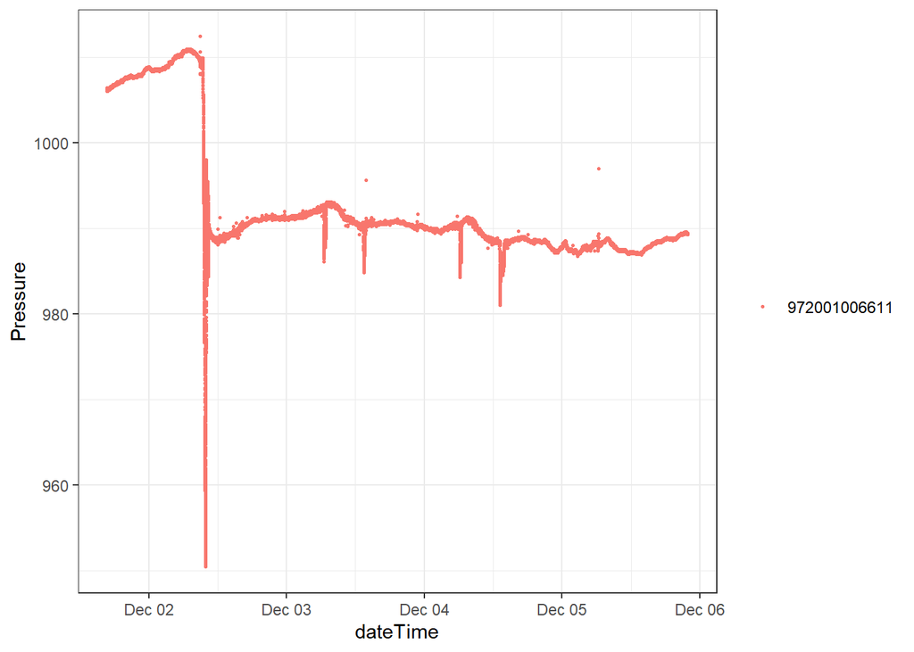

```r
bme.plot.1<-plot_BME(bme.df=pressure_df)
bme.plot.1
```

### read local meteorologic data

The file functions/pressures.R contains “get.ISM.data” function which download pressure and temperature data, from a close meteorologic station.  
In this example - it uses stattion in Har-Knaan, in Tzfat

```r
# ims.token<- Insert token from IMS, and uncomment this line
ism.lst<-get.ISM.data(easting=257000,
                      northing=780000,
                      fromTime=min(pressure_df$TIME),
                      toTime=max(pressure_df$TIME),
                      ims.token)

ism.pressure.df<-ism.lst[["pressure"]]
ism.temperatures.df<-ism.lst[["temeratures"]]
hsl<-ism.lst[["hsl"]]

print(sprintf("Station Heigh relative to sea level=%d meter",hsl))
```

```
## [1] "Station Heigh relative to sea level=936 meter"
```

```r
head(ism.pressure.df)
```

```
##         TIME  value
## 1 1606687200 911.71
## 2 1606687800 911.67
## 3 1606688400 911.68
## 4 1606689000 911.70
## 5 1606689600 911.71
## 6 1606690200 911.62
```

```r
head(ism.temperatures.df)
```

```
##         TIME value
## 1 1606687200  10.8
## 2 1606687800  10.8
## 3 1606688400  10.8
## 4 1606689000  10.8
## 5 1606689600  10.7
## 6 1606690200  10.5
```

(If you get red warning from red.xlsx - it is harmless) lets plot the barometric data, including the refence data, retreived from the local IMS station

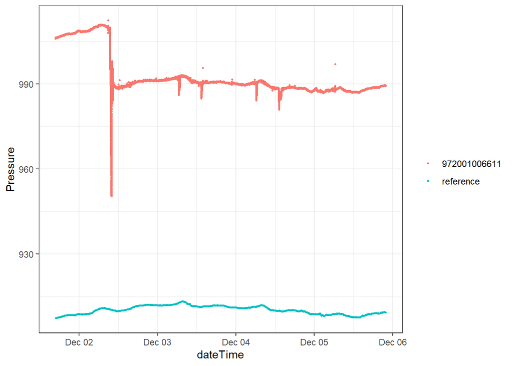

```r
bme.plot.2<-plot_BME(bme.df=pressure_df,
                     reference.df = ism.pressure.df)
bme.plot.2
```

### Estimate Altitude above Sea Level (ASL) by pressure

1. pressure_df - is the sensor’s data
2. ism.pressure.df - a data frame of environment barometric data, as a reference.
3. refTemperature - temperature drymeasurements in IMS station.
4. refAltitude - IMS station high above sea level.

```r
ASL.df<-sensorsPressureToAltitude(pressure=pressure_df,
                                   refPressure=ism.pressure.df,
                                   refTemperature=ism.temperatures.df,
                                   refAltitude=hsl)
```

now - show the altitude plot

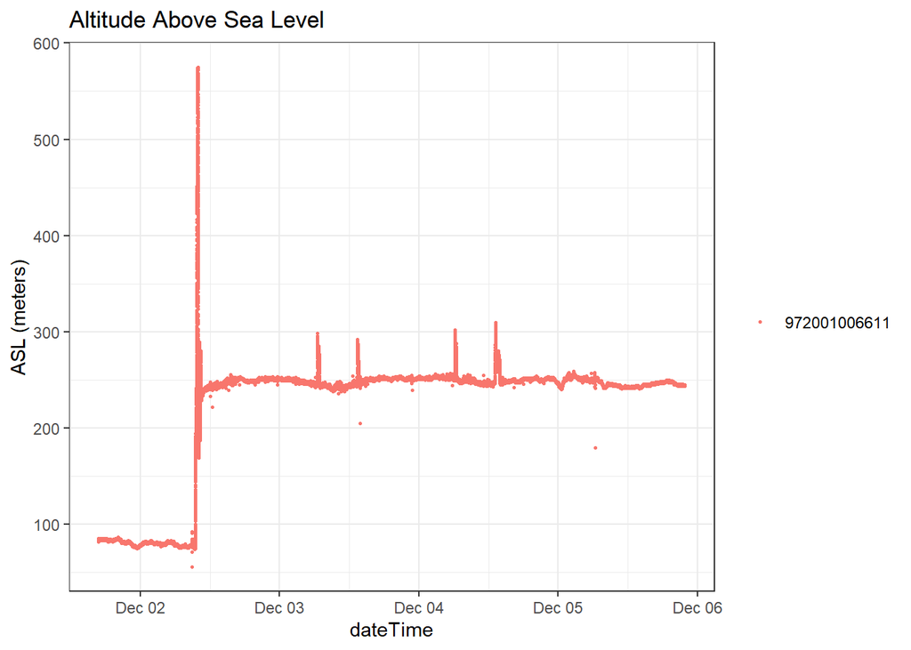

```r
ASL.df$dateTime<-as.POSIXct(ASL.df$TIME, tz="UTC", origin="1970-01-01")
ggplot(ASL.df, aes(x=dateTime, y=ASL))+
  labs(title="Altitude Above Sea Level",
       y="ASL (meters)")+
  geom_point(aes(colour = factor(TAG)), size=0.5)+
  theme_bw()+
  theme(legend.title = element_blank())
```

### integrade ASL with ATLAS TAG data  
now read localization data:

```r
atlas.df<-loadFromSQLite(dbn="data/atlas-6611.sqlite")
glimpse(atlas.df)
```

```
## Rows: 13,101
## Columns: 18
## $ TAG          <int64> 972001006611, 972001006611, 972001006611, 972001006611,~
## $ TX           <int64> -972001006611, 972001006611, 972001006611, -97200100661~
## $ TIME         <int64> 1606841089096, 1606841090096, 1606841091096, 1606841092~
## $ X            <dbl> 255029.89296350, 255001.73339323, 255041.42374671, 255024~
## $ Y            <dbl> 779731.24053381, 779622.83108664, 779688.74807266, 779687~
## $ Z            <dbl> 70, 70, 70, 70, 70, 70, 70, 70, 70, 70, 70, 70, 70, 70, 7~
## $ FREQ         <dbl> 432403931, 432403931, 432403931, 432403931, 432403931, 43~
## $ DIM          <int> 2, 2, 2, 2, 2, 2, 2, 2, 2, 2, 2, 2, 2, 2, 2, 2, 2, 2, 2, ~
## $ NBS          <int> 3, 3, 3, 3, 3, 3, 3, 3, 3, 4, 4, 4, 4, 4, 5, 5, 3, 3, 3, ~
## $ NCONSTRAINTS <int> 3, 3, 3, 3, 3, 3, 3, 3, 3, 4, 4, 4, 4, 4, 5, 5, 3, 3, 3, ~
## $ PENALTY      <dbl> 1.9572700693971e-05, 7.4040099207195e-06, 5.5432301451219~
## $ GRADNRM      <dbl> 3.1707099511051e-14, 3.7169201635816e-14, 6.1087300413140~
## $ VARX         <dbl> 71.633201599121, 78.960800170898, 50.575599670410, 55.535~
## $ VARY         <dbl> 1175.589965820312, 1016.650024414062, 619.432006835938, 7~
## $ VARZ         <dbl> NA, NA, NA, NA, NA, NA, NA, NA, NA, NA, NA, NA, NA, NA, N~
## $ COVXY        <dbl> 252.1549987792969, 252.6809997558594, 82.0776977539062, 1~
## $ COVXZ        <dbl> NA, NA, NA, NA, NA, NA, NA, NA, NA, NA, NA, NA, NA, NA, N~
## $ COVYZ        <dbl> NA, NA, NA, NA, NA, NA, NA, NA, NA, NA, NA, NA, NA, NA, N~
```

dplyr::glimpse() function show each column type. We recommending the following changes :

- If TIME field is int64 , than change TIME field to double - since int64 does not handle well with compering operators
- delete redundant columns to compact the data frame
- it is nice to add dateTime + Date, too
- also - you can change TAG to character (or factor)

```r
atlas.df<-atlas.df%>%
  dplyr::select(-c(TX, Z, DIM, VARZ, COVXZ, COVYZ))%>%
  mutate(TIME=as.double(TIME),
         TAG=as.character(TAG),
         dateTime=as.POSIXct(TIME/1000, tz="UTC",origin="1970-01-01"),
         date=as.Date(dateTime))

glimpse(atlas.df)
```

```
## Rows: 13,101
## Columns: 14
## $ TAG          <chr> "972001006611", "972001006611", "972001006611", "97200100~
## $ TIME         <dbl> 1606841089096, 1606841090096, 1606841091096, 160684109209~
## $ X            <dbl> 255029.89296350, 255001.73339323, 255041.42374671, 255024~
## $ Y            <dbl> 779731.24053381, 779622.83108664, 779688.74807266, 779687~
## $ FREQ         <dbl> 432403931, 432403931, 432403931, 432403931, 432403931, 43~
## $ NBS          <int> 3, 3, 3, 3, 3, 3, 3, 3, 3, 4, 4, 4, 4, 4, 5, 5, 3, 3, 3, ~
## $ NCONSTRAINTS <int> 3, 3, 3, 3, 3, 3, 3, 3, 3, 4, 4, 4, 4, 4, 5, 5, 3, 3, 3, ~
## $ PENALTY      <dbl> 1.9572700693971e-05, 7.4040099207195e-06, 5.5432301451219~
## $ GRADNRM      <dbl> 3.1707099511051e-14, 3.7169201635816e-14, 6.1087300413140~
## $ VARX         <dbl> 71.633201599121, 78.960800170898, 50.575599670410, 55.535~
## $ VARY         <dbl> 1175.589965820312, 1016.650024414062, 619.432006835938, 7~
## $ COVXY        <dbl> 252.1549987792969, 252.6809997558594, 82.0776977539062, 1~
## $ dateTime     <dttm> 2020-12-01 16:44:49, 2020-12-01 16:44:50, 2020-12-01 16:~
## $ date         <date> 2020-12-01, 2020-12-01, 2020-12-01, 2020-12-01, 2020-12-~
```

merge ASL data with ATLAS localizations data, by TIME

```r
  addAtlasLoc <- merge(x=atlas.df%>%
                         mutate(mergeTIME=round(TIME/1000)),
                       y=ASL.df%>%
                         dplyr::select(-dateTime),
                       by.x=c("mergeTIME","TAG"),
                       by.y=c("TIME","TAG"),
                       all.x=TRUE)

  head(addAtlasLoc)
```

```
##    mergeTIME          TAG          TIME               X               Y
## 1 1606841089 972001006611 1606841089096 255029.89296350 779731.24053381
## 2 1606841090 972001006611 1606841090096 255001.73339323 779622.83108664
## 3 1606841091 972001006611 1606841091096 255041.42374671 779688.74807266
## 4 1606841092 972001006611 1606841092096 255024.68909914 779687.82748211
## 5 1606841093 972001006611 1606841093096 255024.07063858 779670.99626320
## 6 1606841095 972001006611 1606841095096 255026.35232204 779657.43367525
##        FREQ NBS NCONSTRAINTS             PENALTY             GRADNRM
## 1 432403931   3            3 1.9572700693971e-05 3.1707099511051e-14
## 2 432403931   3            3 7.4040099207195e-06 3.7169201635816e-14
## 3 432403931   3            3 5.5432301451219e-06 6.1087300413140e-15
## 4 432403931   3            3 1.2870899809059e-05 1.3466800645543e-13
## 5 432403931   3            3 4.9981299042702e-01 1.0661899835229e-10
## 6 432403931   3            3 1.4729799659108e-05 1.7801700123222e-14
##               VARX             VARY            COVXY            dateTime
## 1  71.633201599121 1175.58996582031 252.154998779297 2020-12-01 16:44:49
## 2  78.960800170898 1016.65002441406 252.680999755859 2020-12-01 16:44:50
## 3  50.575599670410  619.43200683594  82.077697753906 2020-12-01 16:44:51
## 4  55.535598754883  787.39099121094 165.828002929688 2020-12-01 16:44:52
## 5 133.440994262695 2212.20996093750 515.559997558594 2020-12-01 16:44:53
## 6  35.866298675537  305.29699707031  25.902299880981 2020-12-01 16:44:55
##         date  Pressure             ASL
## 1 2020-12-01 1006.4202 81.917300260072
## 2 2020-12-01 1006.1500 84.109870665674
## 3 2020-12-01 1006.1317 84.259184414207
## 4 2020-12-01 1006.1047 84.479085347202
## 5 2020-12-01 1006.0595 84.846658805712
## 6 2020-12-01 1006.1214 84.346141819446
```

### Estimate Altitude above Ground Level (AGL) by ASL

now, we use function getAGLFromDEM() which uses the DEM file(s) uploaded to data/DEM/ to calculate AGL

```r
  # get atlitude above ground , using DEM rasters
  AGL.lst<-getAGLFromDEM(addAtlasLoc)
  # the function getAGLFromDEM() return a list with 2 items
  names(AGL.lst)
```

```
## [1] "raster_lst" "atlas.df"
```

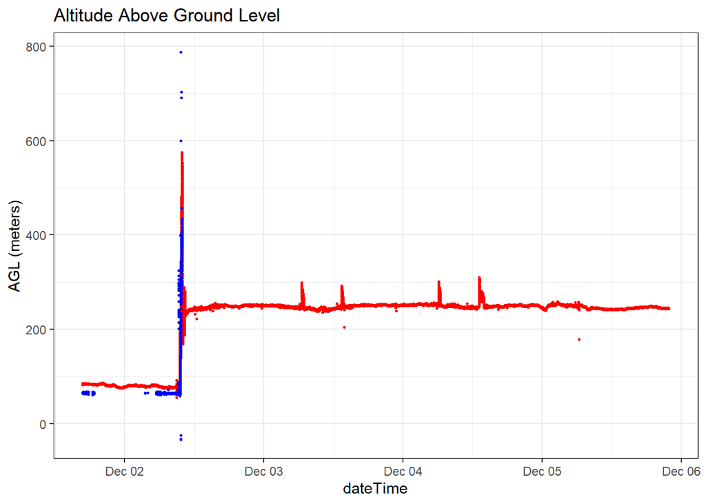

```r
  # extract alas.based data frame from the AGL.lst
  alt.above.ground.df<-AGL.lst[["atlas.df"]]


  #show the altitude plot
  ggplot(ASL.df, aes(x=dateTime, y=ASL))+
    geom_point(color="red", size=0.5)+
    geom_point(data=alt.above.ground.df,
               aes(x=dateTime, y=AGL), color="blue", size=0.5)+
    #scale_x_datetime(limits = as.POSIXct(c('2020-12-02 07:00','2020-12-02 16:00')))+
    labs(title = "Altitude Above Ground Level",
       y="AGL (meters)")+
    theme_bw()+
    theme(legend.title = element_blank())
```

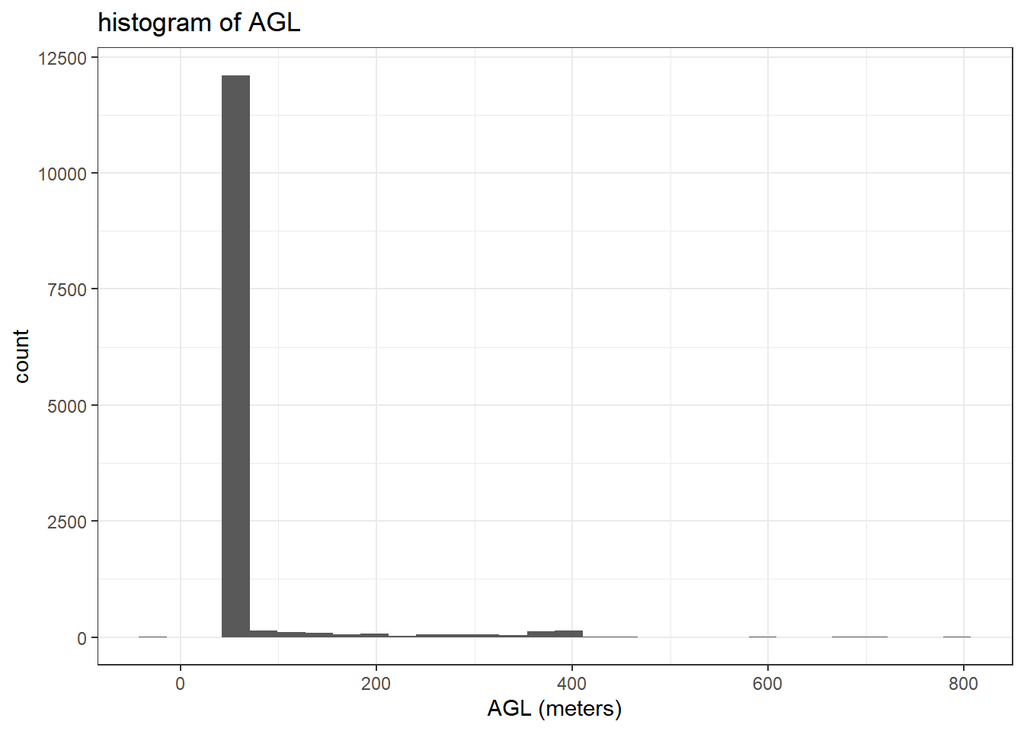

```r
  # show histogram of data's AGL
  ggplot(alt.above.ground.df,)+
    geom_histogram(aes(AGL))+
    labs(title = "histogram of AGL",
      x="AGL (meters)")+
    theme_bw()+
    theme(legend.title = element_blank())
```

lets show the AGL over the geographic map, with leaflet

```r
AGL_ll(alt.above.ground.df)
```

[interactive chart not shown]